# A2 - Predicting Car Prices

Importing the libraries

```python
#Import necessary libraries
import numpy as np
import pandas as pd
import seaborn as sns
import matplotlib.pyplot as plt
import warnings
from sklearn import preprocessing
warnings.filterwarnings('ignore')
```

Loading data

```python
# Load the dataset using pandas and storing them in a dataframe variable
df = pd.read_csv('Cars.csv')
```

```python
# Displaying the first few rows of the dataframe
df.head()
```

|  | name | year | selling_price | km_driven | fuel | seller_type | transmission | owner | mileage | engine | max_power | torque | seats |
| --- | --- | --- | --- | --- | --- | --- | --- | --- | --- | --- | --- | --- | --- |
| 0 | Maruti Swift Dzire VDI | 2014 | 450000 | 145500 | Diesel | Individual | Manual | First Owner | 23.4 kmpl | 1248 CC | 74 bhp | 190Nm@ 2000rpm | 5.0 |
| 1 | Skoda Rapid 1.5 TDI Ambition | 2014 | 370000 | 120000 | Diesel | Individual | Manual | Second Owner | 21.14 kmpl | 1498 CC | 103.52 bhp | 250Nm@ 1500-2500rpm | 5.0 |
| 2 | Honda City 2017-2020 EXi | 2006 | 158000 | 140000 | Petrol | Individual | Manual | Third Owner | 17.7 kmpl | 1497 CC | 78 bhp | 12.7@ 2,700(kgm@ rpm) | 5.0 |
| 3 | Hyundai i20 Sportz Diesel | 2010 | 225000 | 127000 | Diesel | Individual | Manual | First Owner | 23.0 kmpl | 1396 CC | 90 bhp | 22.4 kgm at 1750-2750rpm | 5.0 |
| 4 | Maruti Swift VXI BSIII | 2007 | 130000 | 120000 | Petrol | Individual | Manual | First Owner | 16.1 kmpl | 1298 CC | 88.2 bhp | 11.5@ 4,500(kgm@ rpm) | 5.0 |

```python
#Checking the statistical summary of the dataframe
df.describe()
```

|  | year | selling_price | km_driven | seats |
| --- | --- | --- | --- | --- |
| count | 8128.000000 | 8.128000e+03 | 8.128000e+03 | 7907.000000 |
| mean | 2013.804011 | 6.382718e+05 | 6.981951e+04 | 5.416719 |
| std | 4.044249 | 8.062534e+05 | 5.655055e+04 | 0.959588 |
| min | 1983.000000 | 2.999900e+04 | 1.000000e+00 | 2.000000 |
| 25% | 2011.000000 | 2.549990e+05 | 3.500000e+04 | 5.000000 |
| 50% | 2015.000000 | 4.500000e+05 | 6.000000e+04 | 5.000000 |
| 75% | 2017.000000 | 6.750000e+05 | 9.800000e+04 | 5.000000 |
| max | 2020.000000 | 1.000000e+07 | 2.360457e+06 | 14.000000 |

```python
#Checking the data types and non-null values in the dataframe
df.info()
```

```
<class 'pandas.core.frame.DataFrame'>
RangeIndex: 8128 entries, 0 to 8127
Data columns (total 13 columns):
 #   Column         Non-Null Count  Dtype
---  ------         --------------  -----
 0   name           8128 non-null   object
 1   year           8128 non-null   int64
 2   selling_price  8128 non-null   int64
 3   km_driven      8128 non-null   int64
 4   fuel           8128 non-null   object
 5   seller_type    8128 non-null   object
 6   transmission   8128 non-null   object
 7   owner          8128 non-null   object
 8   mileage        7907 non-null   object
 9   engine         7907 non-null   object
 10  max_power      7913 non-null   object
 11  torque         7906 non-null   object
 12  seats          7907 non-null   float64
dtypes: float64(1), int64(3), object(9)
memory usage: 825.6+ KB
```

```python
#Checking the number of rows and columns in the dataframe
df.shape
```

```
(8128, 13)
```

```python
#Checking the column names in the dataframe
df.columns
```

```
Index(['name', 'year', 'selling_price', 'km_driven', 'fuel', 'seller_type',
       'transmission', 'owner', 'mileage', 'engine', 'max_power', 'torque',
       'seats'],
      dtype='object')
```

```python
#Checking for unique values in "owner" column
df['owner'].unique()
```

```
array(['First Owner', 'Second Owner', 'Third Owner',
       'Fourth & Above Owner', 'Test Drive Car'], dtype=object)
```

# Task 1: Preparing the datasets

Create a mapping dictionary for the 'Owner' column

```python
#Mapping the owner column to numerical values.
ownermap = {
    "First Owner":1,
    "Second Owner":2,
    "Third Owner":3,
    "Fourth & Above Owner":4,
    "Test Drive Car":5
    }
```

```python
#Checking if the owner column exists in the dataframe and then mapping it.
if 'owner' in df.columns:
    df['owner'] = df['owner'].map(ownermap)
```

```python
#Checking if mapping is done correctly
df.owner.unique()
```

```
array([1, 2, 3, 4, 5])
```

Removing the rows of 'Fuel' column with values of LPG and CNG

```python
#Getting the count of unique values in the 'Fuel' column
df['fuel'].unique()
```

```
array(['Diesel', 'Petrol', 'LPG', 'CNG'], dtype=object)
```

```python
#Storing the unique values to remove in an array
fuel_to_remove = ['CNG', 'LPG']
```

```python
#Removing the unwanted fuel types from the dataframe
df = df[~df['fuel'].isin(fuel_to_remove)]
```

```python
#checking if the unwanted fuel types are removed
df['fuel'].unique()
```

```
array(['Diesel', 'Petrol'], dtype=object)
```

Removing "kmpl" and converting the column to numerical type for feature mileage

```python
#Getting the values of mileage column
df['mileage'].head()
```

```
0     23.4 kmpl
1    21.14 kmpl
2     17.7 kmpl
3     23.0 kmpl
4     16.1 kmpl
Name: mileage, dtype: object
```

```python
#Removing the "kmpl" from the mileage column
df['mileage']= df['mileage'].str.split( ).str[0]
```

```python
#Converting the mileage column to float type
df['mileage'] = df['mileage'].astype(float)
```

```python
#Checking if the conversation is done correctly
df['mileage'].dtype
```

```
dtype('float64')
```

Removing "CC" and converting the column to numerical type for feature engine

```python
#Getting the values of 'engine' feature column
df['engine'].head()
```

```
0    1248 CC
1    1498 CC
2    1497 CC
3    1396 CC
4    1298 CC
Name: engine, dtype: object
```

```python
#Removing the 'CC' from the engine column using str.split() method
df['engine'] = df['engine'].str.split( ).str[0]
```

```python
#Verifying the changes in the engine column
df['engine'].head()
```

```
0    1248
1    1498
2    1497
3    1396
4    1298
Name: engine, dtype: object
```

```python
#converting the data type of engine column to float
df['engine'] = df['engine'].astype(float)
```

```python
#verifying the data type of engine column
df['engine'].dtype
```

```
dtype('float64')
```

Removing "bhp" and converting the column to numerical type for feature max_power

```python
#Getting the values of the column 'max_power'
df['max_power'].head()
```

```
0        74 bhp
1    103.52 bhp
2        78 bhp
3        90 bhp
4      88.2 bhp
Name: max_power, dtype: object
```

```python
#Removing the 'bhp' from the max_power column using str.split() method
df['max_power'] = df['max_power'].str.split( ).str[0]
```

```python
#Converting the data type of max_power column to float
df['max_power'] = df['max_power'].astype(float)
```

```python
#Verifying the changes
df['engine'].head()
```

```
0    1248.0
1    1498.0
2    1497.0
3    1396.0
4    1298.0
Name: engine, dtype: float64
```

```python
#Converting the mileage column to float type
df['mileage'] = df['mileage'].astype(float)
```

```python
#Verifying the changes
df['engine'].dtypes
```

```
dtype('float64')
```

Taking only the first word for the feature brand

```python
df.columns
```

```
Index(['name', 'year', 'selling_price', 'km_driven', 'fuel', 'seller_type',
       'transmission', 'owner', 'mileage', 'engine', 'max_power', 'torque',
       'seats'],
      dtype='object')
```

```python
#Renaming the column 'name' to 'brand'
df.rename(columns={'name':'brand'}, inplace=True)
#checking the changes
df.columns
```

```
Index(['brand', 'year', 'selling_price', 'km_driven', 'fuel', 'seller_type',
       'transmission', 'owner', 'mileage', 'engine', 'max_power', 'torque',
       'seats'],
      dtype='object')
```

```python
#Getting information about the column 'brand'
df['brand'].head()
```

```
0          Maruti Swift Dzire VDI
1    Skoda Rapid 1.5 TDI Ambition
2        Honda City 2017-2020 EXi
3       Hyundai i20 Sportz Diesel
4          Maruti Swift VXI BSIII
Name: brand, dtype: object
```

```python
#Only taking the first word from the brand column by using the str.split() method
df['brand'] = df['brand'].str.split( ).str[0]
```

```python
#Verifying the changes
df['brand'].head()
```

```
0     Maruti
1      Skoda
2      Honda
3    Hyundai
4     Maruti
Name: brand, dtype: object
```

Dropping the feature torque

```python
#Removing the feature 'torque' from the dataframe using the drop() method
df = df.drop(['torque'], axis=1)
```

```python
#Removing the 'Owner=5' from the dataframe using the query() method
df = df.query("owner != '5'")
```

```python
#Verifying the changes on the owner column
df['owner'].unique()
```

```
array([1, 2, 3, 4, 5])
```

```python
#Checking the cleaned dataframe
df.head()
```

|  | brand | year | selling_price | km_driven | fuel | seller_type | transmission | owner | mileage | engine | max_power | seats |
| --- | --- | --- | --- | --- | --- | --- | --- | --- | --- | --- | --- | --- |
| 0 | Maruti | 2014 | 450000 | 145500 | Diesel | Individual | Manual | 1 | 23.40 | 1248.0 | 74.00 | 5.0 |
| 1 | Skoda | 2014 | 370000 | 120000 | Diesel | Individual | Manual | 2 | 21.14 | 1498.0 | 103.52 | 5.0 |
| 2 | Honda | 2006 | 158000 | 140000 | Petrol | Individual | Manual | 3 | 17.70 | 1497.0 | 78.00 | 5.0 |
| 3 | Hyundai | 2010 | 225000 | 127000 | Diesel | Individual | Manual | 1 | 23.00 | 1396.0 | 90.00 | 5.0 |
| 4 | Maruti | 2007 | 130000 | 120000 | Petrol | Individual | Manual | 1 | 16.10 | 1298.0 | 88.20 | 5.0 |

Changing the columns 'brand', 'fuel, 'seller_type' and 'trasmission' to numerical format.

```python
#Importing the LabelEncoder from sklearn library
from sklearn.preprocessing import LabelEncoder

#Initializing the LabelEncoder
label_encoder_brand = LabelEncoder()
label_encoder_fuel = LabelEncoder()
label_encoder_seller_type = LabelEncoder()
label_encoder_transmission = LabelEncoder()

#Transforming the categorical columns using the fit_transform() method
df['brand'] = label_encoder_brand.fit_transform(df['brand'])
original_brands = label_encoder_brand.classes_.tolist()
df['fuel'] = label_encoder_fuel.fit_transform(df['fuel'])
df['seller_type'] = label_encoder_seller_type.fit_transform(df['seller_type'])
df['transmission'] = label_encoder_transmission.fit_transform(df['transmission'])
```

```python
#Checking for the changes made
df.head()
```

|  | brand | year | selling_price | km_driven | fuel | seller_type | transmission | owner | mileage | engine | max_power | seats |
| --- | --- | --- | --- | --- | --- | --- | --- | --- | --- | --- | --- | --- |
| 0 | 20 | 2014 | 450000 | 145500 | 0 | 1 | 1 | 1 | 23.40 | 1248.0 | 74.00 | 5.0 |
| 1 | 27 | 2014 | 370000 | 120000 | 0 | 1 | 1 | 2 | 21.14 | 1498.0 | 103.52 | 5.0 |
| 2 | 10 | 2006 | 158000 | 140000 | 1 | 1 | 1 | 3 | 17.70 | 1497.0 | 78.00 | 5.0 |
| 3 | 11 | 2010 | 225000 | 127000 | 0 | 1 | 1 | 1 | 23.00 | 1396.0 | 90.00 | 5.0 |
| 4 | 20 | 2007 | 130000 | 120000 | 1 | 1 | 1 | 1 | 16.10 | 1298.0 | 88.20 | 5.0 |

```python
#Creating a csv of the encoded data set.
df.to_csv('le_cars_data.csv', sep = ',', index=False, encoding='utf-8 ')
```

# Exploratory Data Analysis

```python
#Seperating the numerical and categorical columns from the dataframe
#Excluding the column 'selling_price' from the numerical columns using df.loc method and storing in a variable

df_copy = df.loc[:, df.columns != 'selling_price']

#Seperating the numerical and categorical columns from the dataframe

num_cols = df_copy.select_dtypes(include=['int64', 'float64'])
cat_cols = df_copy.select_dtypes(exclude=['int64', 'float64'])
```

```python
#Verifying the changes made to the dataset
num_cols.columns, cat_cols.columns
```

```
(Index(['brand', 'year', 'km_driven', 'fuel', 'seller_type', 'transmission',
        'owner', 'mileage', 'engine', 'max_power', 'seats'],
       dtype='object'),
 Index([], dtype='object'))
```

# Univariate Analysis

Distribution plot

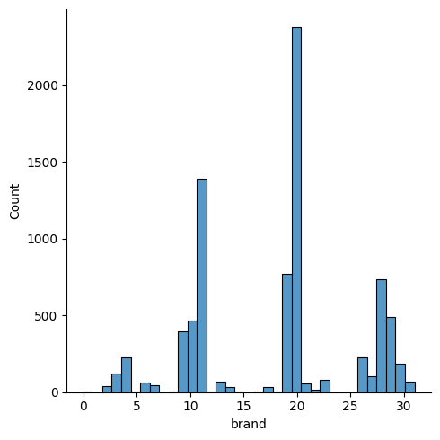

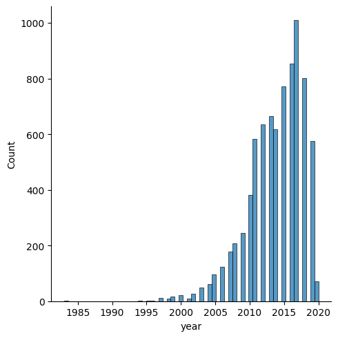

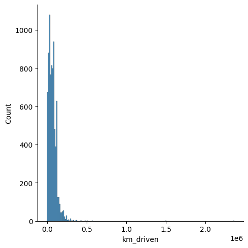

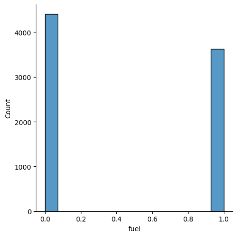

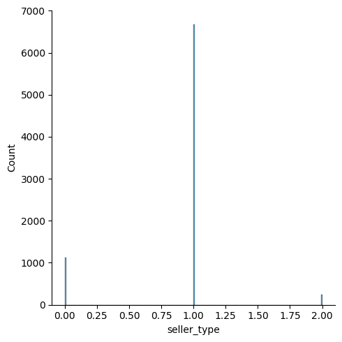

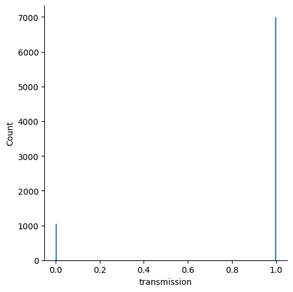

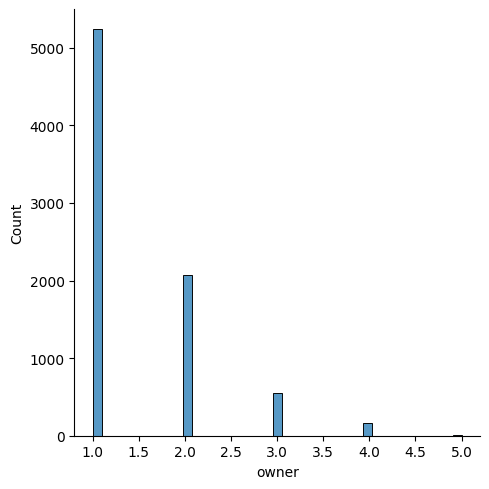

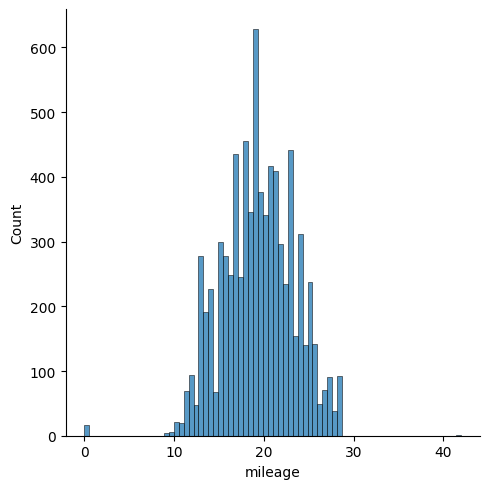

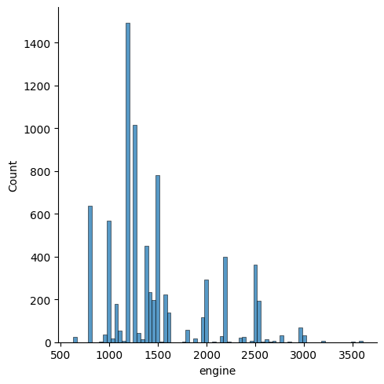

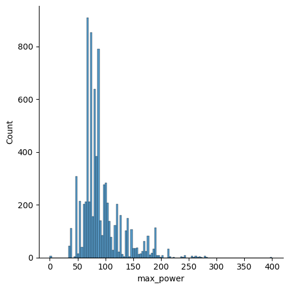

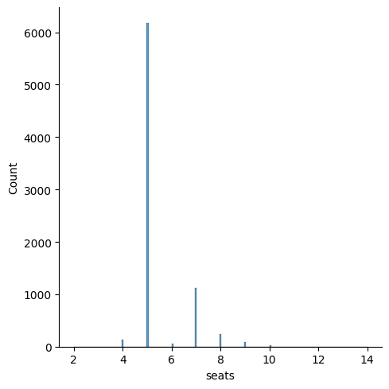

```python
#Analysing the count of all nummerical colums using the distribution plot
for col in num_cols.columns:
    sns.displot(df, x=df[col])
```

# Multivariate Analysis

Scatterplot

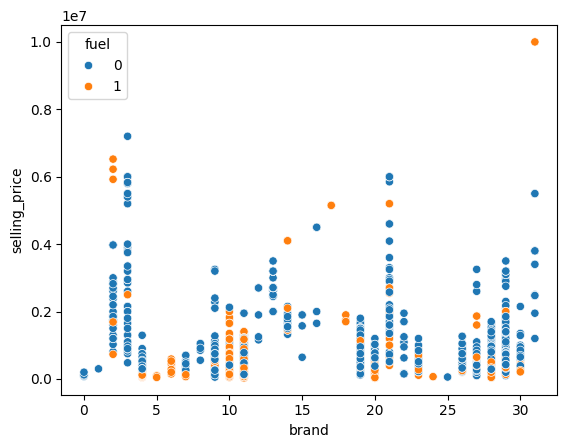

```python
#Plotting the features in the scatter plot to see the relationship between the features and selling_price by keeping fuel as hue
sns.scatterplot(x=df['brand'], y=df['selling_price'], hue=df['fuel'])
```

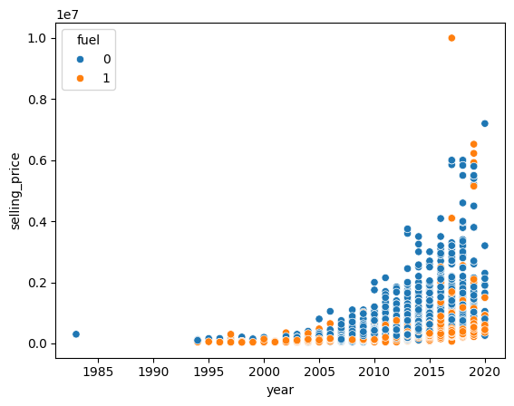

```python
sns.scatterplot(x=df['year'], y=df['selling_price'], hue=df['fuel'])
```

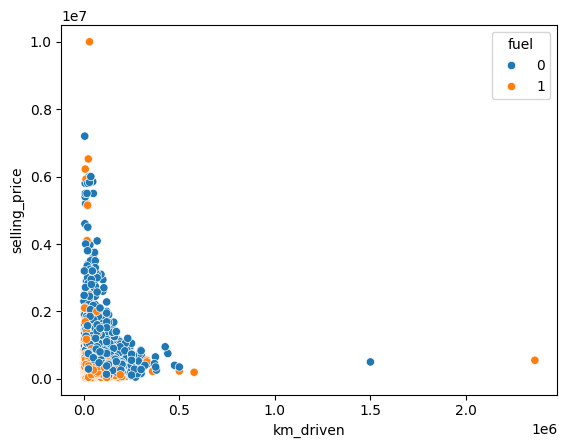

```python
sns.scatterplot(x=df['km_driven'], y=df['selling_price'], hue=df['fuel'])
```

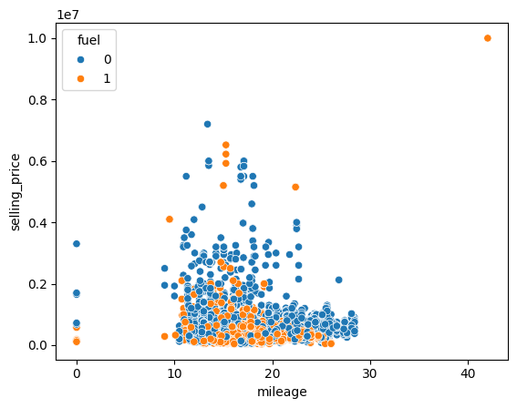

```python
sns.scatterplot(x=df['mileage'], y=df['selling_price'], hue=df['fuel'])
```

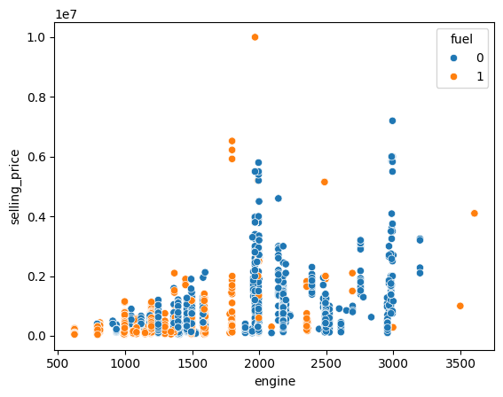

```python
sns.scatterplot(x=df['engine'], y=df['selling_price'], hue=df['fuel'])
```

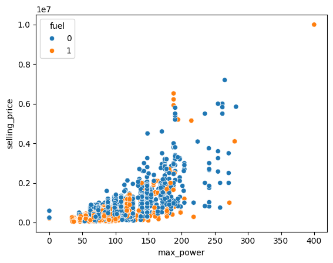

```python
sns.scatterplot(x=df['max_power'], y=df['selling_price'], hue=df['fuel'])
```